# Passenger Traffic Forecasting at Keflavik Airport: A Time Series Analysis

[figure not shown]

In this project, I conduct a time series analysis of the number of passengers passing through Keflavik Airport and attempt to fit a model that predicts the monthly number of passengers for data the model has not seen. The data for the number of passengers passing through Keflavik Airport was obtained from the Iceland Statistics Website: https://statice.is/statistics/business-sectors/tourism/passengers/.

## 1 Get and clean data

First, I obtained the data for the number of passengers passing through Keflavik Airport each month from the year 2018 to February 2024 from the Iceland Statistics website.

```r
data<-read.csv("fardegar.csv", sep = ";")

data$Dagsetning<- as.Date(paste0("01", data$Dagsetning), format = "%d%YM%m")## add 01 in front of each date, and make it a date variable.


## Create test and train data
train<-filter(data, Dagsetning <= "2022-12-01")
test<-filter(data,Dagsetning > "2022-12-01")
```

## 2 Descriptive Statistics

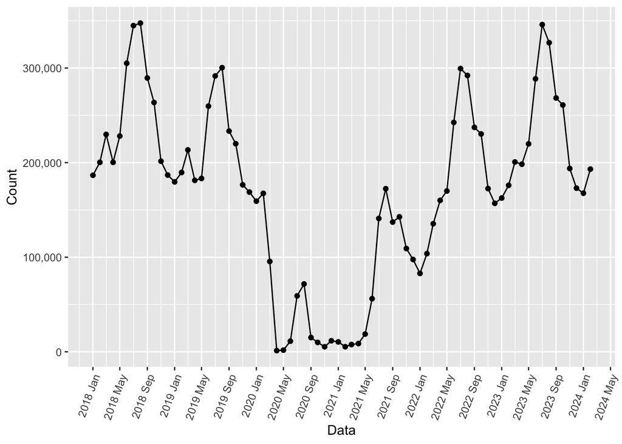

```r
# Find peak points
peak_points <- data[which(diff(sign(diff(data$index))) == -2) + 1, ]

ggplot(data, aes(x= Dagsetning, y = index)) + geom_point()+
                                              geom_line()+
                                              labs(x="Data", y = "Count")+
  scale_y_continuous(labels = comma) +scale_x_date(date_labels = "%Y %b", breaks = "4 months")+ theme(axis.text.x = element_text(angle = 70, hjust = 1))
```

From the picture, we see a clear seasonal pattern in the number of passengers at the airport. There are fewer passengers in the winter months, and the number increases in the summer, usually peaking around June, July, and August. We also observe a drop in the passenger count from March 2020 to July 2021. This decrease can obviously be attributed to the coronavirus pandemic. To further explore our data we will look at some tables.

```r
data%>%
  group_by(Year=year(Dagsetning))%>%

  summarize(Count = sum(index),
            Mean = mean(index),
            SD = sd(index),
            MIN = min(index),
            MIN_Month = month(Dagsetning, label = TRUE)[which.min(index)],
            Max = max(index),
            MAX_Month = month(Dagsetning, label = TRUE)[which.max(index)])%>%kable()
```

| Year | Count | Mean | SD | MIN | MIN_Month | Max | MAX_Month |
| --- | --- | --- | --- | --- | --- | --- | --- |
| 2018 | 2984018 | 248668.17 | 59875.55 | 186636 | Jan | 347475 | Aug |
| 2019 | 2597536 | 216461.33 | 45871.03 | 168850 | Dec | 300366 | Aug |
| 2020 | 609337 | 50778.08 | 60937.53 | 1262 | Apr | 167496 | Feb |
| 2021 | 907058 | 75588.17 | 64259.29 | 5339 | Feb | 172418 | Aug |
| 2022 | 2283435 | 190286.25 | 69814.20 | 82864 | Jan | 299473 | Jul |
| 2023 | 2814780 | 234565.00 | 62085.68 | 162554 | Jan | 345917 | Jul |
| 2024 | 360809 | 180404.50 | 17988.09 | 167685 | Jan | 193124 | Feb |

From the table, we observe that the year 2018 had the highest traffic at Keflavík Airport. There is also a noticeable decline in passenger numbers during the COVID-19 period from 2020 to 2021. In 2023, the count is approaching pre-pandemic levels. Additionally, January typically has lower passenger numbers, while August tends to have higher numbers, although this is not always the case

## 3 See if data is stationary

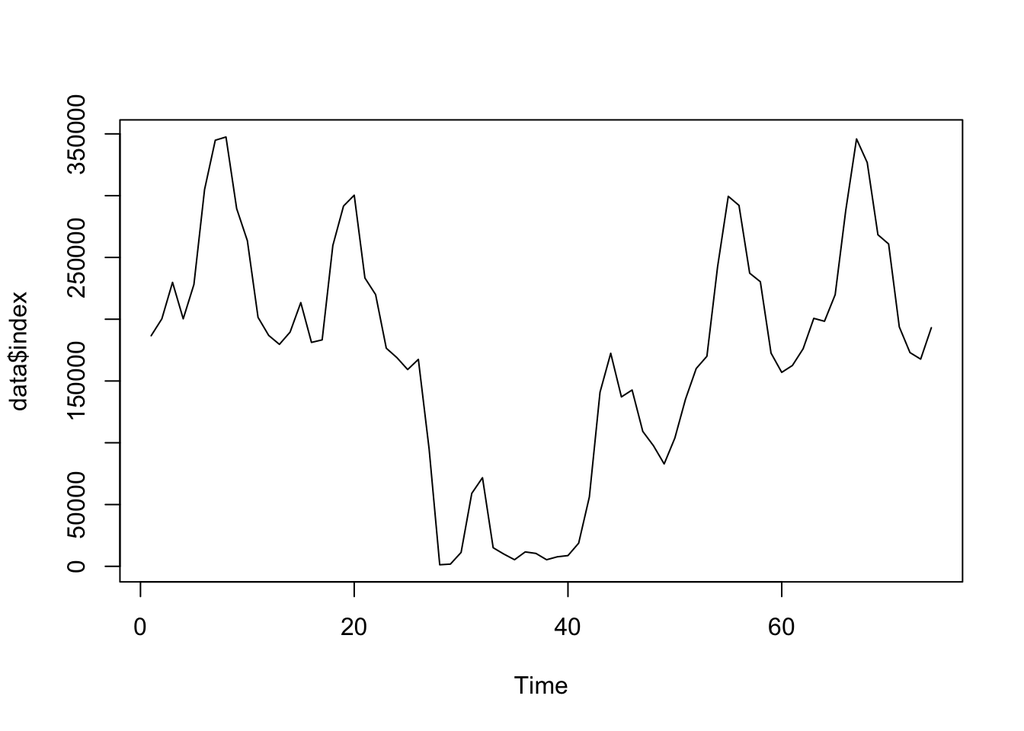

```r
ts.plot(data$index)
```

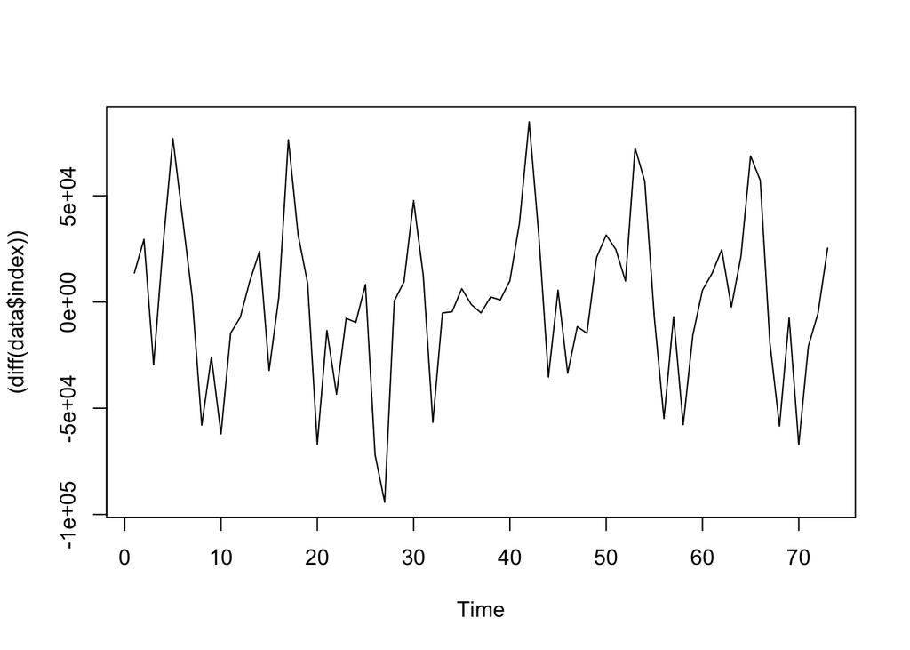

```r
ts.plot((diff(data$index)))
```

To make the data stationary, we need to differentiate the index variable.

### Test for stationary

```r
## test for stationary
adf.test((data$index), alternative="stationary", k=0)
```

```
##
##  Augmented Dickey-Fuller Test
##
## data:  (data$index)
## Dickey-Fuller = -1.6452, Lag order = 0, p-value = 0.7201
## alternative hypothesis: stationary
```

```r
adf.test((diff(data$index)), alternative="stationary", k=0)
```

```
##
##  Augmented Dickey-Fuller Test
##
## data:  (diff(data$index))
## Dickey-Fuller = -5.513, Lag order = 0, p-value = 0.01
## alternative hypothesis: stationary
```

The adf.test confirms that the data must be differenced to be stationary.

## 4 Create the model

```r
## Create a time-series object from the train-date with a monthly frequency, starting from the earliest date from the train-dataþ
ts_data <- ts(train$index, frequency = 12, start = min(data$Dagsetning))


### use auto.arima to find optimal parameters according to AIC
auto.arima(ts_data)
```

```
## Series: ts_data
## ARIMA(1,1,0)(0,1,1)[12]
##
## Coefficients:
##          ar1     sma1
##       0.3800  -0.8322
## s.e.  0.1374   0.6822
##
## sigma^2 = 576747308:  log likelihood = -545.8
## AIC=1097.6   AICc=1098.16   BIC=1103.15
```

```r
## save the best model
arima_model <- auto.arima(ts_data)

## save fitted values
fitt<-fitted(arima_model)
## add fitted values to the train-set
train$fitted<-fitt
```

## 5 Forcast

Here we forecast the number of passengers passing through Keflavik Airport for future months that the model has not seen, or our test data.

```r
## forcast values for the next 14 months(our test-set)
forecast_values <- forecast(arima_model, h = 14)


## add the values to our test-set
test$pred<-forecast_values$mean
```

## Errors.

We’ll use RMSE (Root Mean Squared Error) to see, on average, how much our predictions differ from the actual values

```r
# Residuals
residuals<-test$index-test$pred

# Square the residuals
squared_errors <- residuals^2

# Calculate the mean squared error
mse <- mean(squared_errors)

# Step 4: Calculate RMSE
rmse <- sqrt(mse)

# Print RMSE
print(rmse)
```

```
## [1] 57412.8
```

```r
test$diff<-test$index-test$pred

bla<-test$diff^2

mean<-mean(bla)
bla2<-sqrt(mean)
mean(test$diff)
```

```
## [1] 51923.72
```

```r
test %>%
  rename(Date = Dagsetning,
         Actual = index,
         Difference = diff,
         Predicted = pred)%>%gt()
```

| Date | Actual | Predicted | Difference |
| --- | --- | --- | --- |
| 2023-01-01 | 162554 | 145608.5 | 16945.47 |
| 2023-02-01 | 176036 | 154055.7 | 21980.35 |
| 2023-03-01 | 200693 | 157168.2 | 43524.80 |
| 2023-04-01 | 198333 | 133841.9 | 64491.09 |
| 2023-05-01 | 219827 | 143603.7 | 76223.29 |
| 2023-06-01 | 288593 | 197948.3 | 90644.66 |
| 2023-07-01 | 345917 | 251477.6 | 94439.36 |
| 2023-08-01 | 326782 | 260896.0 | 65886.01 |
| 2023-09-01 | 268355 | 207090.1 | 61264.93 |
| 2023-10-01 | 260912 | 198662.3 | 62249.65 |
| 2023-11-01 | 193788 | 158215.7 | 35572.31 |
| 2023-12-01 | 172990 | 149414.0 | 23576.02 |
| 2024-01-01 | 167685 | 140624.2 | 27060.85 |
| 2024-02-01 | 193124 | 150050.8 | 43073.22 |

From the table, we observe that our highest error occurred in July 2023, where the actual number of passengers was 345,917, but our prediction was 251,477. Conversely, our best prediction was for January 2023, where the actual number of passengers was 162,554, and we predicted 145,608.

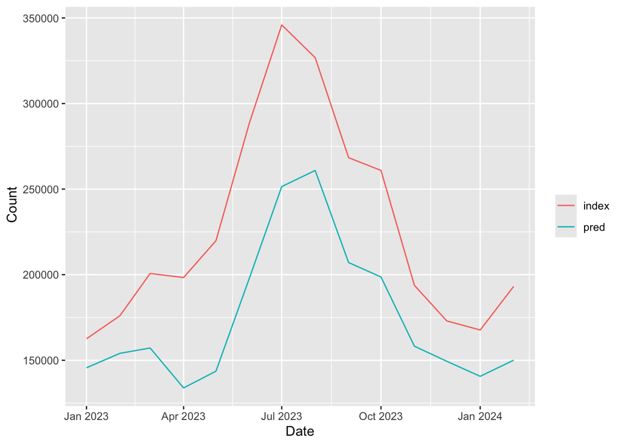

```r
tidy_test <- gather(test, key = "variable", value = "value", pred, index)

ggplot(tidy_test, aes(x = Dagsetning, y = value, color = variable)) +
  geom_line(data = subset(tidy_test, !(variable == "pred" & value == 0))) +
  labs(x="Date", y=" Count", color= " ")
```

We can observe that the actual number of passengers passing through Keflavik Airport is consistently higher than our predicted number. Nevertheless, our model appears to effectively capture the seasonal variations in passenger numbers